# 10조

오상훈 / 2016125039 / 팀원: 김태훈, 백윤성, 이해인

```python
import torch.nn as nn
import torch
from torchvision import datasets
from torchvision import transforms
from torch.utils.data import DataLoader
import numpy as np
import torch.optim as optim
import matplotlib.pyplot as plt
```

```python
# 모델 구성하기
class Net(nn.Module):
    def __init__(self):
        super(Net, self).__init__()
        self.fc1 = nn.Linear(784,100)
        self.relu = nn.ReLU()
        self.fc2 = nn.Linear(100,100)
        self.fc3 = nn.Linear(100,10)

    def forward(self, x):
        x1 = self.fc1(x)
        x2 = self.relu(x1)
        x3 = self.fc2(x2)
        x4 = self.relu(x3)
        x5 = self.fc3(x4)

        return x5
```

```python
#xavier를 적용하기 위한 함수
def xavier_init(model):
    torch.nn.init.xavier_uniform_(model.fc1.weight)
    torch.nn.init.xavier_uniform_(model.fc2.weight)
    torch.nn.init.xavier_uniform_(model.fc3.weight)
```

```python
# he(kaim)을 적용하기 위한 함수
def kaiming_init(model):
    torch.nn.init.kaiming_uniform_(model.fc1.weight)
    torch.nn.init.kaiming_uniform_(model.fc2.weight)
    torch.nn.init.kaiming_uniform_(model.fc3.weight)
```

```python
download_root = 'MNIST_data/'
```

```python
dataset1 = datasets.MNIST(root=download_root,
                         train=True,
                         transform = transforms.ToTensor(),
                         download=True)
```

```python
dataset2 = datasets.MNIST(root=download_root,
                         train=False,
                         transform=transforms.ToTensor(),
                         download=True)
```

```python
# DataLoader를 이용해서 batch size 정하기(batch size는 100으로 지정)
batch_s = 100
dataset1_loader = DataLoader(dataset1, batch_size=batch_s, shuffle=True)
dataset2_loader = DataLoader(dataset2, batch_size=batch_s, shuffle=True)
```

```python
# 각 케이스에 대한 model 정보, loss, accuracy 정보를 저장하기 위한 딕셔너리 생성
model_dict = {}
loss_dict = {}
accuracy_dict = {}

# 총 12가지의 케이스를 정의(optimizer만 사용한 것, optimizer+초기화)
case_list = ['SGD','Adam','AdaGrad','RMSprop','SGDxavier', \
             'Adamxavier','AdaGradxavier','RMSpropxavier', \
            'SGDkaim','Adamkaim','AdaGradkaim','RMSpropkaim']

# optimizer이름을 key로 정함
for key in case_list:
    model_dict[key] = Net()
    loss_dict[key]=[]
    accuracy_dict[key]=[]

    # xavier와 he의 경우 위에서 선언한 함수를 호출하여 초기화 적용
    if 'xavier' in key:
        xavier_init(model_dict[key])
        model_dict[key] = nn.Sequential(model_dict[key].fc1, model_dict[key].relu, \
                                       model_dict[key].fc2, model_dict[key].relu,\
                                       model_dict[key].fc3)
    elif 'kaim' in key:
        kaiming_init(model_dict[key])
        model_dict[key] = nn.Sequential(model_dict[key].fc1, model_dict[key].relu, \
                                       model_dict[key].fc2, model_dict[key].relu,\
                                       model_dict[key].fc3)
```

```python
# 위에서 정의한 12가지 모델에 대해서 각각 optimizer 설정하기
learning_rate = 0.01
optimizer_dict = {}

optimizer_dict['SGD'] = optim.SGD(model_dict['SGD'].parameters(), lr=learning_rate)
optimizer_dict['SGDxavier'] = optim.SGD(model_dict['SGDxavier'].parameters(), lr=learning_rate)
optimizer_dict['SGDkaim'] = optim.SGD(model_dict['SGDkaim'].parameters(), lr=learning_rate)

optimizer_dict['Adam'] = optim.Adam(model_dict['Adam'].parameters(), lr=learning_rate)
optimizer_dict['Adamxavier'] = optim.Adam(model_dict['Adamxavier'].parameters(), lr=learning_rate)
optimizer_dict['Adamkaim'] = optim.Adam(model_dict['Adamkaim'].parameters(), lr=learning_rate)

optimizer_dict['AdaGrad'] = optim.Adagrad(model_dict['AdaGrad'].parameters(), lr=learning_rate)
optimizer_dict['AdaGradxavier'] = optim.Adagrad(model_dict['AdaGradxavier'].parameters(), lr=learning_rate)
optimizer_dict['AdaGradkaim'] = optim.Adagrad(model_dict['AdaGradkaim'].parameters(), lr=learning_rate)

optimizer_dict['RMSprop'] = optim.RMSprop(model_dict['RMSprop'].parameters(), lr=learning_rate)
optimizer_dict['RMSpropxavier'] = optim.Adagrad(model_dict['RMSpropxavier'].parameters(), lr=learning_rate)
optimizer_dict['RMSpropkaim'] = optim.Adagrad(model_dict['RMSpropkaim'].parameters(), lr=learning_rate)
```

```python
# loss function, total_batch size, epoch 정의
loss_function = nn.CrossEntropyLoss()
total_batch = len(dataset1_loader)
epochs = np.arange(1,16)
print(len(dataset1_loader)) #60000개의 data를 batch_size를 100으로 했기 때문에 600이 나오는 것.
```

```
600
```

```python
# 총 12가지 케이스의 loss와 accuracy를 한 번에 담아주려고 한다.
# optimizer_name에는 optimizer_dict로 들어간 키 값이, optimizer에는 optimizer를 적용한 내용이 들어간다.
for optimizer_name, optimizer in optimizer_dict.items(): #총 15회 학습
    model_dict[optimizer_name].zero_grad()
    #print("optimizer : ",optimizer_name)
    for epoch in epochs:
        cost=0
        for images, labels in dataset1_loader:
            images = images.reshape(100,784)

            optimizer.zero_grad() # 변화도 매개변수 0

            #초기화를 사용하지 않는 모델들에 대한 forward
            if(optimizer_name == 'SGD' or optimizer_name=='Adam' \
               or optimizer_name=='AdaGrad' or optimizer_name == 'RMSprop'):
                pred = model_dict[optimizer_name].forward(images)
            elif('xavier' in optimizer_name):
                #xavier 초기화 방법 사용
                pred = model_dict[optimizer_name](images)
            elif('kaim' in optimizer_name):
                #he(kaim) 초기화 방법 사용
                pred = model_dict[optimizer_name](images)

            # loss값 구하기
            loss = loss_function(pred, labels)

            #backward(Back propagation)
            loss.backward()

            #Update(weight update 진행)
            optimizer.step()

            # 600번을 반복한 loss의 결과가 다 더해짐
            cost += loss

        # 제대로 학습이 되었는지 테스트 해보는 과정
        with torch.no_grad(): #미분하지 않겠다는 것
            total = 0
            correct=0
            for images, labels in dataset2_loader:
                images = images.reshape(100,784)

                outputs = model_dict[optimizer_name](images)
                _,predict = torch.max(outputs.data, 1)

                total += labels.size(0)
                correct += (predict==labels).sum() # 예측한 값과 일치한 값의 합

        avg_cost = cost / total_batch
        accuracy = 100*correct/total

        loss_dict[optimizer_name].append(avg_cost.detach().numpy())
        accuracy_dict[optimizer_name].append(accuracy)

        #print("epoch : {} | loss : {:.6f}" .format(epoch, avg_cost))
        #print("Accuracy : {:.2f}".format(100*correct/total))
        #print("------")
print("finished")
```

```
finished
```

# 과제 1. 지난주에 만들었던 인공신경망의 Loss vs 학습량, 정확도 vs 학습량

- optimizer를 SGD로 사용했을 때 epoch에 따른 loss와 accuracy 변화를 나타낸 것이다.
- 학습이 진행될수록 loss 값을 줄어들고, accuracy는 증가한다.

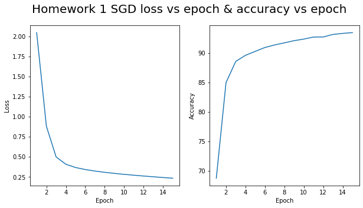

```python
# 과제 1. 지난주에 만들었던 인공신경망의 Loss vs 학습량, 정확도 vs 학습량
# optimizer를 SGD로 사용했을 때 epoch에 따른 loss와 accuracy 변화
# 학습이 진행될수록 loss 값을 줄어들고, accuracy는 증가한다.
plt.figure(figsize=(10,5))
plt.subplot(1,2,1)
plt.xlabel('Epoch')
plt.ylabel('Loss')
plt.plot(epochs,loss_dict['SGD'])
plt.subplot(1,2,2)
plt.xlabel('Epoch')
plt.ylabel('Accuracy')
plt.plot(epochs, accuracy_dict['SGD'])
plt.suptitle("Homework 1 SGD loss vs epoch & accuracy vs epoch", fontsize=20)
plt.show()
```

# 과제 2. 위 주제 중 1개를 반영하여 인공신경망의 Loss vs 학습량, 정확도 vs 학습량

- optimizer로 adam, adagrd, RMSprop를 사용했을 때 epoch에 따른 loss와 accuracy 변화를 나타내었다.
- adagrad를 적용했을 때 가장 안정적으로 loss가 줄어들고 정확도가 증가하였다.

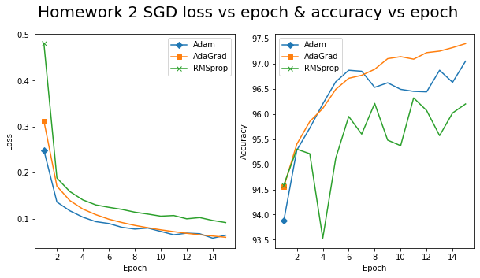

```python
# 과제 2. 위 주제 중 1개를 반영하여 인공신경망의 Loss vs 학습량, 정확도 vs 학습량
# optimizer로 adam, adagrd, RMSprop를 사용했을 때 epoch에 따른 loss와 accuracy 변화
# adagrad를 적용했을 때 가장 안정적으로 loss가 줄어들고 정확도가 증가
markers =  {"SGD": "o","RMSprop": "x", "AdaGrad": "s", "Adam": "D"}

plt.figure(figsize=(10,5))
plt.subplot(1,2,1)
for key in optimizer_dict.keys():
    if key=='RMSprop' or key=='AdaGrad' or key=='Adam':
        plt.plot(epochs, loss_dict[key], marker=markers[key], markevery=100, label=key)
plt.xlabel("Epoch")
plt.ylabel("Loss")
plt.legend()

plt.subplot(1,2,2)
for key in optimizer_dict.keys():
    if key=='RMSprop' or key=='AdaGrad' or key=='Adam':
        plt.plot(epochs, accuracy_dict[key], marker=markers[key], markevery=100, label=key)
plt.xlabel('Epoch')
plt.ylabel('Accuracy')
plt.legend()

plt.suptitle("Homework 2 SGD loss vs epoch & accuracy vs epoch", fontsize=20)
plt.show()
```

# 과제 3. 다른 1개를 반영하여 인공신경망의 Loss vs 학습량, 정확도 vs 학습량

- optimizer SGD에 xavier 방식과 he 방식을 각각 적용해봤을 때 epoch에 따른 loss와 accuracy 출력하였다.
- 초기화 방식으로 xavier보다 he(kaim)을 썼을 때 더 좋은 성능을 보였다.

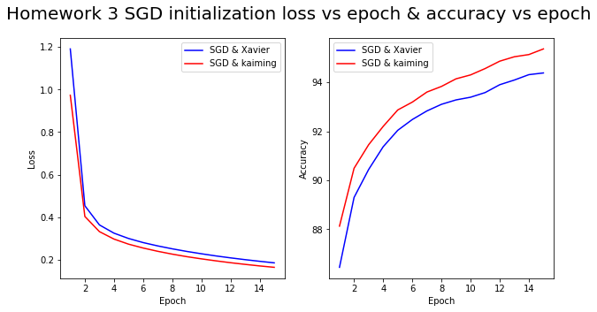

```python
# 과제 3. 위 주제 중 다른 1개를 반영하여 인공신경망의 Loss vs 학습량, 정확도 vs 학습량
# optimizer SGD에 xavier 방식과 he 방식을 각각 적용해봤을 때 epoch에 따른 loss와 accuracy 출력
# 초기화 방식으로 he(kaim)을 썼을 때 더 좋은 성능을 보였다.
plt.figure(figsize=(10,5))
plt.subplot(1,2,1)
plt.xlabel('Epoch')
plt.ylabel('Loss')
plt.plot(epochs,loss_dict['SGDxavier'],'b',label='SGD & Xavier')
plt.plot(epochs,loss_dict['SGDkaim'],'r',label='SGD & kaiming')
plt.legend()

plt.subplot(1,2,2)
plt.xlabel('Epoch')
plt.ylabel('Accuracy')
plt.plot(epochs, accuracy_dict['SGDxavier'],'b',label='SGD & Xavier')
plt.plot(epochs, accuracy_dict['SGDkaim'],'r',label='SGD & kaiming')
plt.legend()

plt.suptitle("Homework 3 SGD initialization loss vs epoch & accuracy vs epoch", fontsize=20)
plt.show()
```

# 과제 4. 위 주제 중 2개를 반영하여 인공 신경망의 Loss vs 학습량, 정확도 vs 학습량

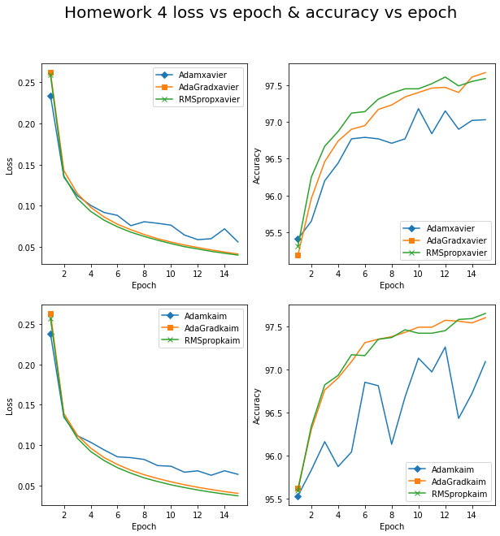

```python
# 과제 4. 위 주제 중 2개를 반영하여 인공 신경망의 Loss vs 학습량, 정확도 vs 학습량
markers =  {"SGDxavier": "o","RMSpropxavier": "x", "AdaGradxavier": "s", "Adamxavier": "D"}

plt.figure(figsize=(10,10))
plt.subplot(2,2,1)
for key in optimizer_dict.keys():
    if key=='RMSpropxavier' or key=='AdaGradxavier' or key=='Adamxavier' :
        plt.plot(epochs, loss_dict[key], marker=markers[key], markevery=100, label=key)
plt.xlabel("Epoch")
plt.ylabel("Loss")
plt.legend()

plt.subplot(2,2,2)
for key in optimizer_dict.keys():
    if key=='RMSpropxavier' or key=='AdaGradxavier' or key=='Adamxavier':
        plt.plot(epochs, accuracy_dict[key], marker=markers[key], markevery=100, label=key)
plt.xlabel('Epoch')
plt.ylabel('Accuracy')
plt.legend()

markers =  {"SGDkaim": "o","RMSpropkaim": "x", "AdaGradkaim": "s", "Adamkaim": "D"}
plt.subplot(2,2,3)
for key in optimizer_dict.keys():
    if key=='RMSpropkaim' or key=='AdaGradkaim' or key=='Adamkaim' :
        plt.plot(epochs, loss_dict[key], marker=markers[key], markevery=100, label=key)
plt.xlabel("Epoch")
plt.ylabel("Loss")
plt.legend()

plt.subplot(2,2,4)
for key in optimizer_dict.keys():
    if key=='RMSpropkaim' or key=='AdaGradkaim' or key=='Adamkaim':
        plt.plot(epochs, accuracy_dict[key], marker=markers[key], markevery=100, label=key)
plt.xlabel('Epoch')
plt.ylabel('Accuracy')
plt.legend()


plt.suptitle("Homework 4 loss vs epoch & accuracy vs epoch", fontsize=20)
plt.show()
```